# lab4

## Лабораторная работа 4

# Загрузка данных о котах

```r
library(MASS)
data(cats)
summary(cats)
```

```
##  Sex         Bwt             Hwt
##  F:47   Min.   :2.000   Min.   : 6.30
##  M:97   1st Qu.:2.300   1st Qu.: 8.95
##         Median :2.700   Median :10.10
##         Mean   :2.724   Mean   :10.63
##         3rd Qu.:3.025   3rd Qu.:12.12
##         Max.   :3.900   Max.   :20.50
```

У нас 47 кошек и 97 котов. Средний вес сердца

```r
mean(cats$Hwt)
```

```
## [1] 10.63056
```

Cреднеквадратичное отклонение

```r
sd(cats$Hwt)
```

```
## [1] 2.434636
```

Дисперсия

```r
var(cats$Hwt)
```

```
## [1] 5.927451
```

рассчитайте параметры a и s. Округлите до разумного числа знаков

```r
a=round(mean(cats$Hwt)**2/var(cats$Hwt),3)
s=round(var(cats$Hwt)/mean(cats$Hwt),3)
a
```

```
## [1] 19.065
```

```r
s
```

```
## [1] 0.558
```

Напишите функцию для расчёта параметров a и s через дисперсию и среднее для передаваемого вектора чисел. Функция должна зазываться my.gamma и возвращать рассчитанные параметры в виде именованного вектора.

```r
 my.gamma <- function(x)
{
   a = round(mean(x)**2/var(x), 3)
   s = round(var(x)/mean(x), 3)
   return(c(a,s))
}
```

```r
my.gamma(cats$Hwt)
```

```
## [1] 19.065  0.558
```

Результаты идентичны

Постройте гистограмму весов. Добавьте на гистограмму кривую плотности вероятности при помощи функций curve и dgamma, указав ранее найденные параметры формы и масштаба.

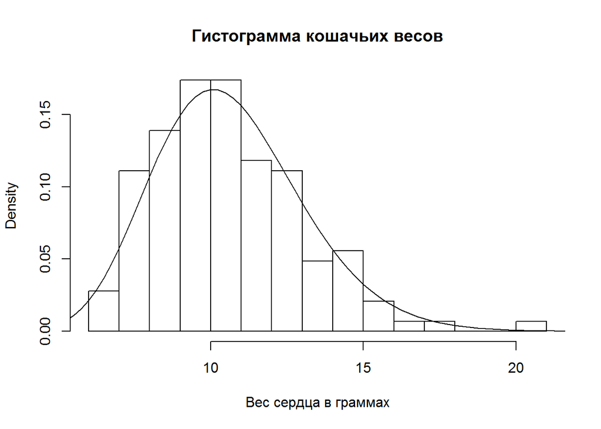

```r
hist(cats$Hwt, main = "Гистограмма кошачьих весов", xlab = "Вес сердца в граммах", prob=TRUE,breaks = 20)
curve(dgamma(x, shape = a, scale = s), from = 0, to = 25,add=TRUE)
```

Получите параметры a и s отдельно для котов и кошек, использовав функцию my.gamma.

```r
Catboys = subset(cats, cats$Sex == "F")
Catgirls = subset(cats, cats$Sex == "M")
asCatgirls = my.gamma(Catgirls$Hwt)
asCatboys = my.gamma(Catboys$Hwt)
```

Постройте полученные функции распределения на одном графике, используя curve и dgamma.

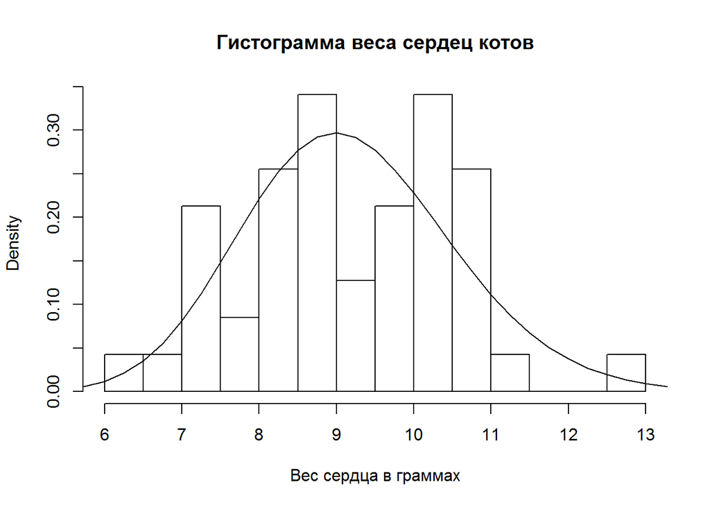

```r
hist(Catboys$Hwt, main = "Гистограмма веса сердец котов", xlab = "Вес сердца в граммах", prob=TRUE,breaks = 20)
curve(dgamma(x, shape = asCatboys[1], scale = asCatboys[2]), from = 0, to = 25,add=TRUE)
```

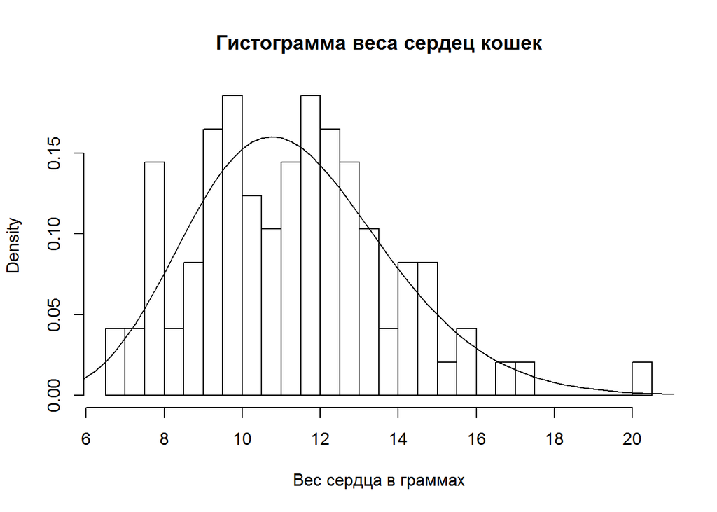

```r
hist(Catgirls$Hwt, main = "Гистограмма веса сердец кошек", xlab = "Вес сердца в граммах", prob=TRUE,breaks = 20)
curve(dgamma(x, shape = asCatgirls[1], scale = asCatgirls[2]), from = 0, to = 25,add=TRUE)
```

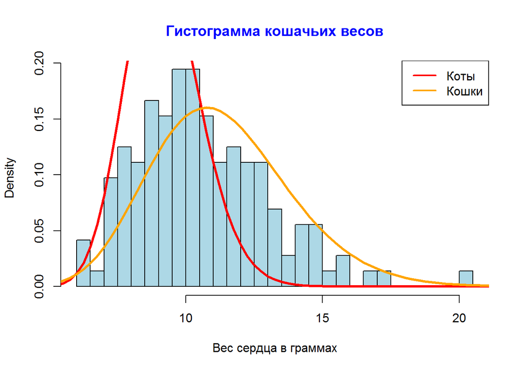

```r
hist(cats$Hwt, main = "Гистограмма кошачьих весов", xlab = "Вес сердца в граммах", prob=TRUE,breaks = 25,col.main = "blue", col = "lightblue")
legend("topright", legend = c("Коты", "Кошки"),
lwd=2, col=c("red","orange"))
curve(dgamma(x, shape = asCatboys[1], scale = asCatboys[2]), from = 0, to = 25, add=TRUE, lwd = 3,col = "red")
curve(dgamma(x, shape = asCatgirls[1], scale = asCatgirls[2]), from = 0, to = 25,add=TRUE, lwd = 3, col= "orange")
```

Случайным образом разделите данные на две группы одного размера равного количеству котов и кошек соответственно. Получите гамма-параметры для обеих групп. Повторите эксперимент несколько раз. Найдите среднюю разницу между результатами групп.

```r
CM1 = sample(cats$Hwt, nrow(Catboys))
CM2 = sample(cats$Hwt, nrow(Catgirls))
asCM1 = my.gamma(CM1)
asCM2 = my.gamma(CM2)
CM3 = sample(cats$Hwt, nrow(Catboys))
CM4 = sample(cats$Hwt, nrow(Catgirls))
asCM3 = my.gamma(CM3)
asCM4 = my.gamma(CM4)
CM5 = sample(cats$Hwt, nrow(Catboys))
CM6 = sample(cats$Hwt, nrow(Catgirls))
asCM5 = my.gamma(CM5)
asCM6 = my.gamma(CM6)
CM7 = sample(cats$Hwt, nrow(Catboys))
CM8 = sample(cats$Hwt, nrow(Catgirls))
asCM7 = my.gamma(CM7)
asCM8 = my.gamma(CM8)
```

```r
dfCatboys=matrix(c(asCM1[1],asCM3[1],asCM5[1],asCM7[1],asCM1[2],asCM3[2],asCM5[2],asCM7[2]), nrow=4, ncol=2)
dfCatboys=data.frame(dfCatboys)
names(dfCatboys)[1] = "a"
names(dfCatboys)[2] = "s"
dfCatgirls=matrix(c(asCM2[1],asCM4[1],asCM6[1],asCM8[1],asCM2[2],asCM4[2],asCM6[2],asCM8[2]), nrow=4, ncol=2)
dfCatgirls=data.frame(dfCatgirls)
names(dfCatgirls)[1] = "a"
names(dfCatgirls)[2] = "s"
dfCatboys
```

```
##        a     s
## 1 17.334 0.656
## 2 16.846 0.617
## 3 18.824 0.569
## 4 15.208 0.746
```

```r
dfCatgirls
```

```
##        a     s
## 1 17.286 0.621
## 2 19.517 0.543
## 3 20.556 0.512
## 4 20.540 0.523
```

```r
colMeans(dfCatboys)
```

```
##      a      s
## 17.053  0.647
```

```r
colMeans(dfCatgirls)
```

```
##        a        s
## 19.47475  0.54975
```

```r
print(a)
```

```
## [1] 19.065
```

```r
print(s)
```

```
## [1] 0.558
```

```r
a-mean(dfCatboys$a)
```

```
## [1] 2.012
```

```r
s-mean(dfCatboys$s)
```

```
## [1] -0.089
```

```r
a-mean(dfCatgirls$a)
```

```
## [1] -0.40975
```

```r
s-mean(dfCatgirls$s)
```

```
## [1] 0.00825
```

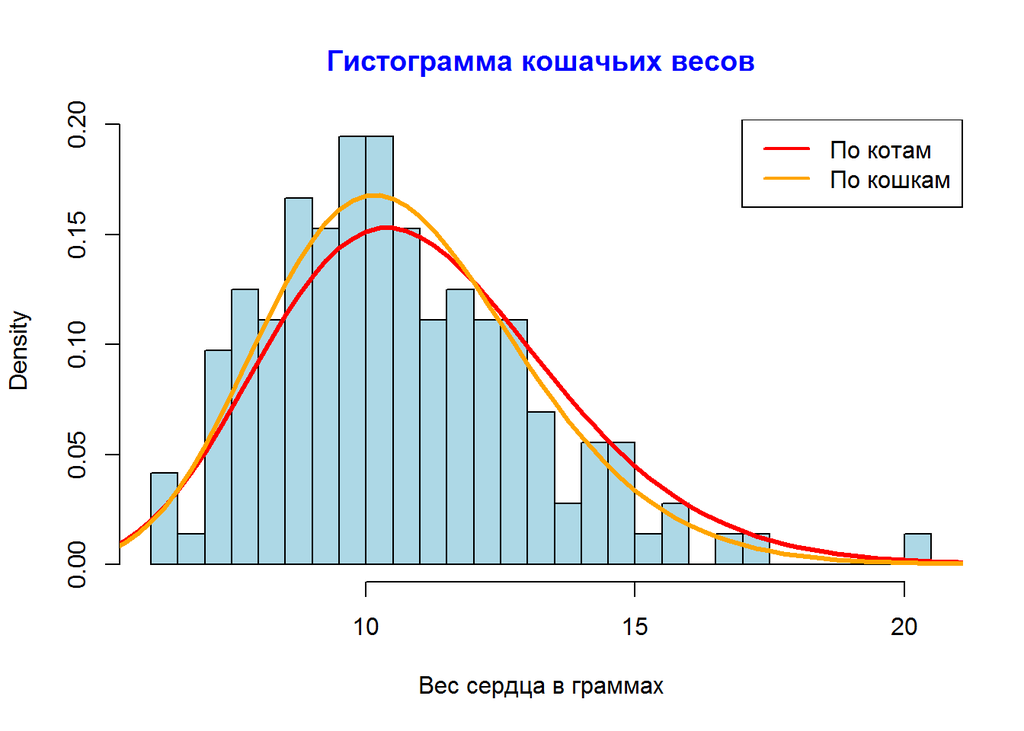

```r
hist(cats$Hwt, main = "Гистограмма кошачьих весов", xlab = "Вес сердца в граммах", prob=TRUE,breaks = 25,col.main = "blue", col = "lightblue")
legend("topright", legend = c("По котам", "По кошкам"),
lwd=2, col=c("red","orange"))
curve(dgamma(x, shape = colMeans(dfCatboys)[1], scale = colMeans(dfCatboys)[2]), from = 0, to = 25, add=TRUE, lwd = 3,col = "red")
curve(dgamma(x, shape = colMeans(dfCatgirls)[1], scale = colMeans(dfCatgirls)[2]), from = 0, to = 25,add=TRUE, lwd = 3, col= "orange")
```